# GR5243 - Project 1 - What made you happy today?

hl3148 Hongru Liu

## Introduction

In this data blog, I explore the text in the HappyDB, which contains more than 100,000 happy moments from over 10,000 contributors. The most interesting question I think is that “what the most common topics are people interested in?”

In order to answer the previous question, I fit an LDA topic model by using Gibbs sampling, to create a 10-topic LDA model. Then, I plot several bar plots to get more insights into each fitted topics. Finally, I use the LDA model to answer the following questions:

- Which countries have more common happy moments?
- What are the differences in happiness between people of different marital status?

## Step 0. Check and install needed packages. Load the needed functions.

## Step 1. Topic Modeling

**Load the processed moments and demographic data.**

**Gengerate document-term matrices.**

```
## [1] 100392  19095
```

**And remove the empty rows.**

```
## [1] 100376  19095
```

**Run LDA**

**Write out results to csv files.**

```
##
##     1     2     3     4     5     6     7     8     9    10
## 16827 12150 11593 10803  5769 10893  8864  9639  7395  6453
```

## Step 2. Word-topic probabilities

```
##       Topic 1     Topic 2      Topic 3    Topic 4   Topic 5
##  [1,] "found"     "day"        "time"     "morning" "feel"
##  [2,] "bought"    "son"        "family"   "dog"     "moment"
##  [3,] "received"  "daughter"   "enjoyed"  "night"   "life"
##  [4,] "car"       "event"      "visit"    "hours"   "happiness"
##  [5,] "money"     "school"     "house"    "love"    "people"
##  [6,] "shopping"  "told"       "home"     "home"    "makes"
##  [7,] "purchased" "college"    "day"      "cat"     "person"
##  [8,] "buy"       "class"      "spend"    "sleep"   "live"
##  [9,] "free"      "excited"    "brother"  "run"     "love"
## [10,] "store"     "mother"     "trip"     "cleaned" "positive"
## [11,] "pay"       "smile"      "weekend"  "laugh"   "experience"
## [12,] "card"      "graduation" "kids"     "couple"  "world"
## [13,] "expected"  "parents"    "spent"    "woke"    "joy"
## [14,] "online"    "child"      "planned"  "coffee"  "share"
```

[output cut: 27 more lines]

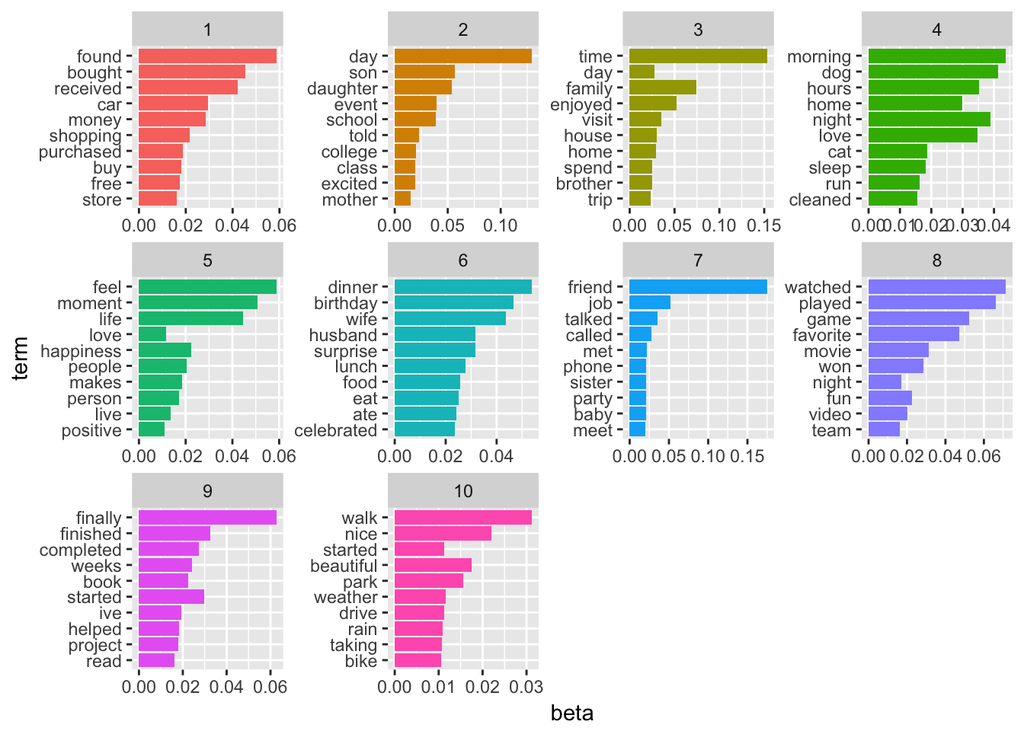

Based on the above plots and the most popular terms, a hashtag is manually assigned to each topic.

## Step 3. Clutser Plot: Which countries have more common happy moments?

By combining the demographic information and the LDA model, I plot 101 countries into 5 clusters, using the k-means clustering method.

```
## `summarise_each()` is deprecated.
## Use `summarise_all()`, `summarise_at()` or `summarise_if()` instead.
## To map `funs` over all variables, use `summarise_all()`
```

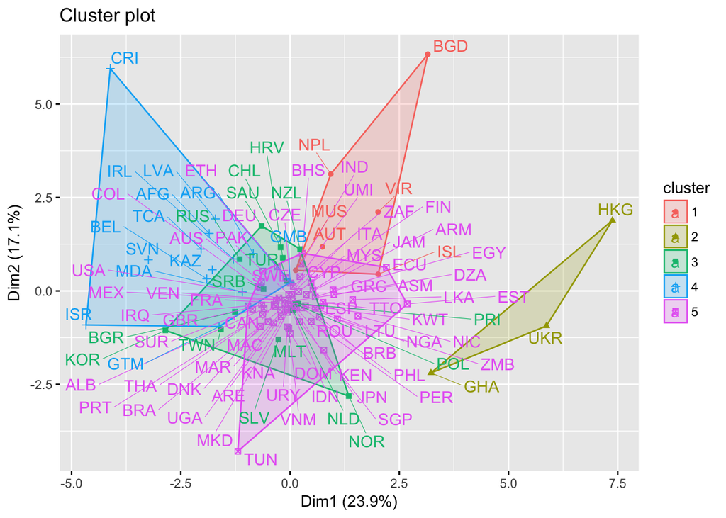

## Step 4. Heatmap: What are differences in happiness between people in different marital status ?

```
## `summarise_each()` is deprecated.
## Use `summarise_all()`, `summarise_at()` or `summarise_if()` instead.
## To map `funs` over all variables, use `summarise_all()`
```

```
##  [1] "Shopping"       "School"         "Family"         "Pet"
##  [5] "Life"           "SpecialEvent"   "Friend"         "Enterntainment"
##  [9] "Success"        "Travel"
```

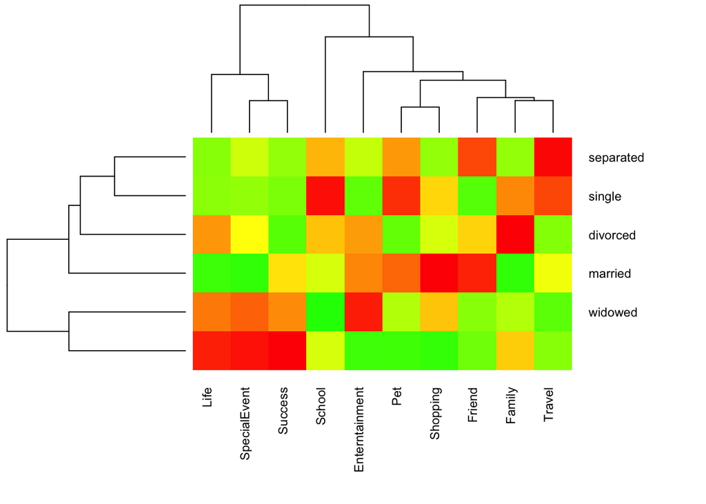

As we can see from the graph above, all the contributors are divided into six different marital status, separated, single, divorced, married, widowed and undefined (the last row). Not surprisingly, the most popular topics among **single people** are **school**, **pet** and **travel**, since the single people are most likely the younger people or students, and children always love pets. **Married people**, on the contrary, are most interested in **Shopping** and **friends**. But the most uncommon thing I notice is that for **divorced people**, **Family** is the most popular topics.